# Exploratory Data Analysis on the Washigton crime report

# 4.7) Seasonal Crime pattern

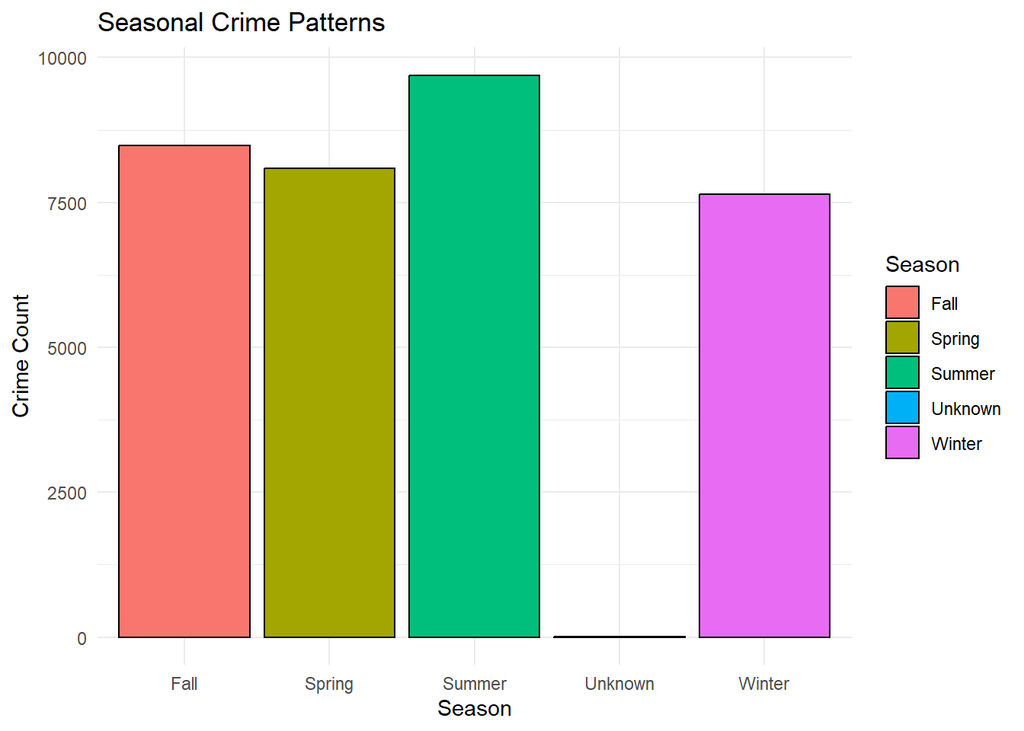

```r
# Ensure START_DATE is in Date format
crime_data2$START_DATE <- as.Date(crime_data2$START_DATE)

# Extract year and month
crime_data2$Year <- format(crime_data2$START_DATE, "%Y")  # Extracting the year as a string
crime_data2$Month <- format(crime_data2$START_DATE, "%b")  # Extracting abbreviated month names

# Define seasons based on months (northern hemisphere)
crime_data2$Season <- case_when(
  crime_data2$Month %in% c("Dec", "Jan", "Feb") ~ "Winter",
  crime_data2$Month %in% c("Mar", "Apr", "May") ~ "Spring",
  crime_data2$Month %in% c("Jun", "Jul", "Aug") ~ "Summer",
  crime_data2$Month %in% c("Sep", "Oct", "Nov") ~ "Fall",
  TRUE ~ "Unknown"  # Catch-all for any unexpected month values
)

# Group by season and summarize total crime count per season
crime_by_season <- crime_data2 %>%
  group_by(Season) %>%
  summarise(Count = n(), .groups = 'drop')

# Group by month and summarize total crime count per month
crime_by_month <- crime_data2 %>%
  group_by(Month) %>%
  summarise(Count = n(), .groups = 'drop')

# Plot crime counts by season to identify seasonal patterns
ggplot(crime_by_season, aes(x = Season, y = Count, fill = Season)) +
  geom_bar(stat = "identity", color = "black") +
  labs(title = "Seasonal Crime Patterns", x = "Season", y = "Crime Count") +
  theme_minimal()
```

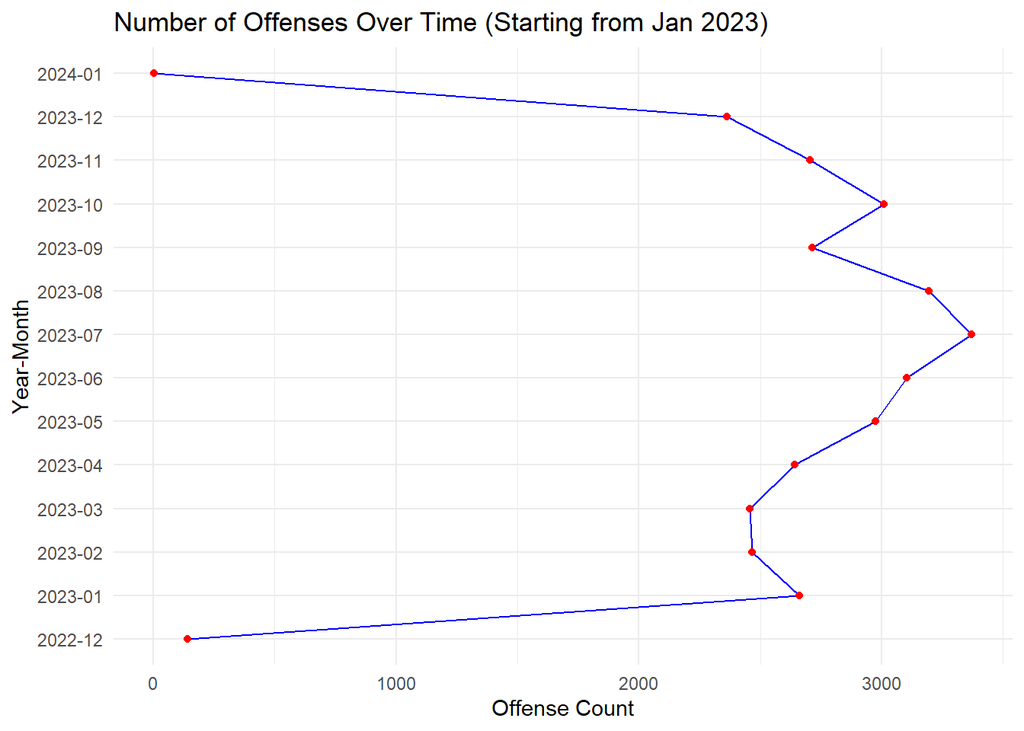

```r
# Ensure date columns are in proper date format
crime_data2$START_DATE <- as.Date(crime_data2$START_DATE)

# Extract the year and month from the START_DATE column
crime_data2$YearMonth <- format(crime_data2$START_DATE, "%Y-%m")

# Filter the data to include only from January 2023
crime_data_filtered <- crime_data2 %>%
  filter(YearMonth >= "2022-12")

# Group by YearMonth and count the number of offenses
offense_by_month <- crime_data_filtered %>%
  group_by(YearMonth) %>%
  summarise(Count = n(), .groups = 'drop')

# Plot the temporal analysis (Offenses by Month) with flipped coordinates
ggplot(offense_by_month, aes(x = YearMonth, y = Count, group = 1)) +
  geom_line(color = "blue") +
  geom_point(color = "red") +
  labs(title = "Number of Offenses Over Time (Starting from Jan 2023)", x = "Year-Month", y = "Offense Count") +
  theme(axis.text.x = element_text(angle = 90, hjust = 1)) +
  coord_flip() +  # Flip the x and y axes
  theme_minimal()
```

# 4.8) shift vs offence

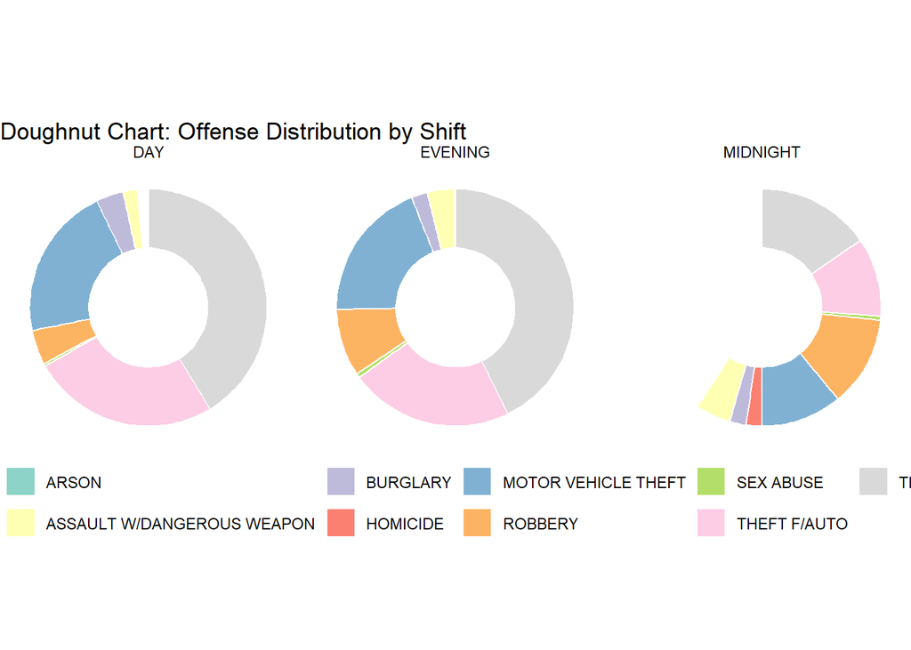

```r
# Summarize the count of offenses by SHIFT and OFFENSE
offense_by_shift_summary <- crime_data2 %>%
  group_by(SHIFT, OFFENSE) %>%
  summarise(Total_Offenses = n(), .groups = 'drop')


ggplot(offense_by_shift_summary, aes(x = 2, y = Total_Offenses, fill = OFFENSE)) +
  geom_bar(stat = "identity", width = 1, color = "white") +
  coord_polar(theta = "y") +
  xlim(0.5, 2.5) +
  theme_void() +
  facet_wrap(~ SHIFT) +
  labs(title = "Doughnut Chart: Offense Distribution by Shift") +
  scale_fill_brewer(palette = "Set3") +
  theme(legend.position = "bottom")
```

```r
library(dplyr)
library(ggplot2)

offense_summary <- crime_data2 %>%
  group_by(OFFENSE) %>%
  summarise(Count = n(), .groups = 'drop') %>%
  arrange(desc(Count))

offense_summary
```

```
## # A tibble: 9 × 2
##   OFFENSE                    Count
##   <chr>                      <int>
## 1 THEFT/OTHER                13078
## 2 THEFT F/AUTO                7690
## 3 MOTOR VEHICLE THEFT         6736
## 4 ROBBERY                     3450
## 5 ASSAULT W/DANGEROUS WEAPON  1392
## 6 BURGLARY                    1079
## 7 HOMICIDE                     274
## 8 SEX ABUSE                    189
## 9 ARSON                         11
```

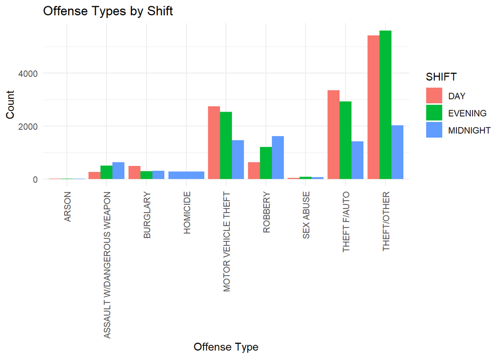

```r
# Summarize offense counts by Shift
offense_by_shift <- crime_data2 %>%
  group_by(SHIFT, OFFENSE) %>%
  summarise(Count = n(), .groups = 'drop')

# Create a bar plot to visualize offenses by shift
ggplot(offense_by_shift, aes(x = OFFENSE, y = Count, fill = SHIFT)) +
  geom_bar(stat = "identity", position = "dodge") +
  labs(title = "Offense Types by Shift", x = "Offense Type", y = "Count") +
  theme_minimal() +
  theme(axis.text.x = element_text(angle = 90, hjust = 1, vjust = 0.5))
```

# 4.8) coorrelation–

between numerical variables x,y ,ward, latitude , longitude

```r
# Select numeric columns for correlation analysis
numeric_columns <- crime_data2 %>%
  select(X, Y, LATITUDE, LONGITUDE, PSA, WARD, DISTRICT)

# Check the structure of numeric columns
str(numeric_columns)
```

```
## 'data.frame':    33899 obs. of  7 variables:
##  $ X        : num  0.369 0.394 0.468 0.365 0.434 ...
##  $ Y        : num  0.656 0.976 0.525 0.501 0.631 ...
##  $ LATITUDE : num  0.656 0.976 0.525 0.501 0.631 ...
##  $ LONGITUDE: num  0.369 0.394 0.468 0.365 0.434 ...
##  $ PSA      : int  302 401 308 207 304 701 103 101 209 302 ...
##  $ WARD     : Factor w/ 8 levels "1","2","3","4",..: 1 4 2 2 1 8 6 2 2 1 ...
##  $ DISTRICT : int  3 4 3 2 3 7 1 1 2 3 ...
```

```r
# Convert non-numeric columns to numeric (if necessary)
numeric_columns <- crime_data2 %>%
  select(X, Y, LATITUDE, LONGITUDE, PSA, WARD, DISTRICT) %>%
  mutate(across(everything(), ~ as.numeric(.)))

# Check structure to confirm all columns are now numeric
str(numeric_columns)
```

```
## 'data.frame':    33899 obs. of  7 variables:
##  $ X        : num  0.369 0.394 0.468 0.365 0.434 ...
##  $ Y        : num  0.656 0.976 0.525 0.501 0.631 ...
##  $ LATITUDE : num  0.656 0.976 0.525 0.501 0.631 ...
##  $ LONGITUDE: num  0.369 0.394 0.468 0.365 0.434 ...
##  $ PSA      : num  302 401 308 207 304 701 103 101 209 302 ...
##  $ WARD     : num  1 4 2 2 1 8 6 2 2 1 ...
##  $ DISTRICT : num  3 4 3 2 3 7 1 1 2 3 ...
```

# correlation_matrix -

```r
# Calculate the correlation matrix
correlation_matrix <- cor(numeric_columns, use = "complete.obs")

# Print the correlation matrix
print(correlation_matrix)
```

```
##                X      Y LATITUDE LONGITUDE    PSA   WARD DISTRICT
## X          1.000 -0.453   -0.453     1.000  0.624  0.723    0.623
## Y         -0.453  1.000    1.000    -0.453 -0.343 -0.611   -0.339
## LATITUDE  -0.453  1.000    1.000    -0.453 -0.343 -0.611   -0.339
## LONGITUDE  1.000 -0.453   -0.453     1.000  0.624  0.723    0.623
## PSA        0.624 -0.343   -0.343     0.624  1.000  0.540    1.000
## WARD       0.723 -0.611   -0.611     0.723  0.540  1.000    0.540
## DISTRICT   0.623 -0.339   -0.339     0.623  1.000  0.540    1.000
```

```r
# Set a CRAN mirror
options(repos = c(CRAN = "https://cloud.r-project.org/"))

# Load necessary libraries or install if not available
if (!requireNamespace("corrplot", quietly = TRUE)) {
  install.packages("corrplot")
}
```

# 4.8) Correlation plot.

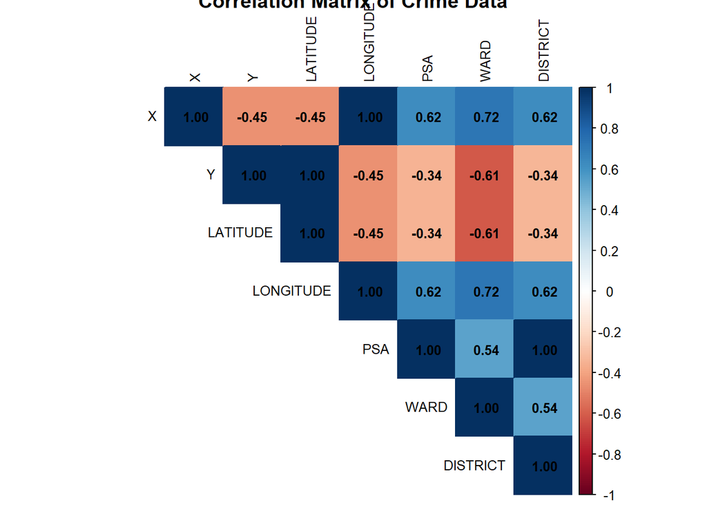

```r
library(corrplot)


# Calculate the correlation matrix
correlation_matrix <- cor(numeric_columns, use = "complete.obs")

# Plot the correlation matrix using corrplot
corrplot(correlation_matrix, method = "color", type = "upper",
         tl.col = "black", tl.cex = 0.8, number.cex = 0.8,
         addCoef.col = "black", title = "Correlation Matrix of Crime Data")
```

```r
library(ggplot2)
library(sf)
library(dplyr)
library(tidycensus)
```

```r
library(devtools)

#devtools::install_github("BingoLaHaye/DCmapR")
```

```r
library(DCmapR)
#devtools::install_github("BingoLaHaye/DCmapR")
```

# 5) Stastical Test–

Lets start with the Stastical test now

# 5.1) Chi-Square Test Results - (shift and offence type)

chi-square test fir shift and offence type. Null Hypothesis (H0): There is no association between Shift and Offense type.

Alternative Hypothesis (H1): There is an association between Shift and Offense type. This indicates that the distribution of offense types is dependent on the time of day (Shift).

The Chi-Square Test Results we have done between Shift and Offence Type. And we got the result as follow 1) Test Statistic (X-squared): 3258 2) Degrees of Freedom (df): 16 3) P-value: < 2e-16 - As the P value is very less than 0.05 we can say that, there is a statistically significant association between the time of day (Shift) and the types of offenses recorded in your data. In practical terms, this means that the frequency of different offense types varies significantly depending on whether the incident occurred during the day, evening, or midnight shifts.

```r
# Load necessary library
library(dplyr)

# Create a contingency table for Shift and Offense
table_shift_offense <- table(crime_data2$SHIFT, crime_data2$OFFENSE)

# Run the Chi-square test
chi_square_shift_offense <- chisq.test(table_shift_offense)

# Print the results
print(chi_square_shift_offense)
```

```
##
##  Pearson's Chi-squared test
##
## data:  table_shift_offense
## X-squared = 3258, df = 16, p-value <2e-16
```

# 5.2 Fisher-test (shift and offence type)

As we can see that , we have have less frequency than 5 in the shift. so we have a alter native test called as Fisher-test. Reults from the Fisher-Test.

Null Hypothesis (H0): There is no association between Shift and Offense type.

Alternative Hypothesis (H1): There is an association between Shift and Offense type. This indicates that the distribution of offense types is dependent on the time of day (Shift).

we reject the null hypothesis (H0). This indicates that there is a statistically significant association between the time of day (shift) and the type of offense committed.

```r
# If your table is small enough
# Create the contingency table
contingency_table_shift_offense <- table(crime_data2$SHIFT, crime_data2$OFFENSE)

fisher_test_result <- fisher.test(contingency_table_shift_offense, simulate.p.value = TRUE)
print(fisher_test_result)
```

```
##
##  Fisher's Exact Test for Count Data with simulated p-value (based on
##  2000 replicates)
##
## data:  contingency_table_shift_offense
## p-value = 5e-04
## alternative hypothesis: two.sided
```

# 5.3 Chi-squard test( shift vs method)

Null Hypothesis (H0): There is no association between the shift and the method used in offenses (i.e., the distribution of methods is the same across shifts) Alternative Hypothesis (H1): There is an association between the shift and the method used in offenses (i.e., the distribution of methods varies across shifts).

Test Statistic- df=4 p value-2e-16

```r
# Create a contingency table
contingency_table_shift_method <- table(crime_data2$SHIFT, crime_data2$METHOD)

# first we will do  Chi-squared test
chi_squared_result <- chisq.test(contingency_table_shift_method)

print(chi_squared_result)
```

```
##
##  Pearson's Chi-squared test
##
## data:  contingency_table_shift_method
## X-squared = 2399, df = 4, p-value <2e-16
```

# 5.4)Fisher-test (shift and method )

p-value is much lower than the common significance level so we reject the null hypothesis and accept the alternative hypotheis test.

```r
# now we are verifing the result with the fisher test-
fisher_result <- fisher.test(contingency_table_shift_method, simulate.p.value = TRUE)
print(fisher_result)
```

```
##
##  Fisher's Exact Test for Count Data with simulated p-value (based on
##  2000 replicates)
##
## data:  contingency_table_shift_method
## p-value = 5e-04
## alternative hypothesis: two.sided
```

```r
head(crime_data2)
```

```
##        CCN REPORT_DAT Year Month    SHIFT METHOD             OFFENSE
## 1 23120415 2023-07-25 2023   Jul MIDNIGHT OTHERS             ROBBERY
## 2 23047033 2023-03-27 2023   Mar MIDNIGHT    GUN             ROBBERY
## 3 23187303 2023-11-15 2023   Nov      DAY OTHERS         THEFT/OTHER
## 4 23055316 2023-04-10 2023   Apr MIDNIGHT OTHERS        THEFT F/AUTO
## 5 23056311 2023-04-11 2023   Apr  EVENING OTHERS MOTOR VEHICLE THEFT
## 6 23156424 2023-09-22 2023   Sep      DAY OTHERS             ROBBERY
##                                                  BLOCK WARD ANC DISTRICT PSA
## 1                    1600 - 1699 BLOCK OF PARK ROAD NW    1  1D        3 302
## 2              8129  - 8148 BLOCK OF EASTERN AVENUE NW    4  4A        4 401
## 3                       400 - 499 BLOCK OF O STREET NW    2  2G        3 308
## 4                  1100 - 1129 BLOCK OF 17TH STREET NW    2  2C        2 207
## 5                   700 - 999 BLOCK OF HOBART PLACE NW    1  1E        3 304
## 6 1900 - 1999 BLOCK OF MARTIN LUTHER KING JR AVENUE SE    8  8A        7 701
##   NEIGHBORHOOD_CLUSTER BLOCK_GROUP CENSUS_TRACT VOTING_PRECINCT             BID
```

[output cut: 27 more lines]

# 5.5) ANOVA- Analysis of Variance,

from the below annova test, ans – method used to commit offenses has a statistically significant effect on the count of offenses.

Null Hypothesis (H0): There is no significant effect of the method used (e.g., GUN, OTHERS) on the count of offenses.

Alternative Hypothesis (H1): At least one method has a significant effect on the count of offenses. The p-value (0.00034) is less than 0.05, so we reject the null hypothesis.

and for the type of offence and count of offence. Null Hypothesis (H0): There is no significant effect of the type of offense (e.g., ROBBERY, THEFT/OTHER) on the count of offenses.

Alternative Hypothesis (H1): At least one type of offense has a significant effect on the count of offenses.

```r
library(dplyr)

# Create a summarized data frame counting occurrences of offenses by SHIFT and METHOD
summary_data <- crime_data2 %>%
  group_by(SHIFT, METHOD, OFFENSE) %>%
  summarise(Count = n(), .groups = 'drop')

# Convert SHIFT and METHOD to factors if not already
summary_data$SHIFT <- as.factor(summary_data$SHIFT)
summary_data$METHOD <- as.factor(summary_data$METHOD)


# Perform ANOVA using Count as the dependent variable
anova_result <- aov(Count ~ SHIFT + METHOD + OFFENSE, data = summary_data)

# Print the summary of ANOVA results
summary(anova_result)
```

```
##             Df   Sum Sq Mean Sq F value  Pr(>F)
## SHIFT        2  1266688  633344    0.66 0.51960
## METHOD       2 18052238 9026119    9.46 0.00034 ***
## OFFENSE      8 20869559 2608695    2.73 0.01416 *
## Residuals   49 46771175  954514
## ---
## Signif. codes:  0 '***' 0.001 '**' 0.01 '*' 0.05 '.' 0.1 ' ' 1
```

The results suggest that the timing of “GUN” offenses varies significantly by shift, with a greater number of occurrences during MIDNIGHT compared to DAY and EVENING. This finding could have implications for law enforcement and crime prevention strategies, indicating a need for targeted resource allocation during specific times.

```r
# Load necessary library
library(dplyr)

# Assuming 'data' is your data frame
# Step 1: Filter the data for method "GUN"
gun_data <- crime_data2 %>%
  filter(METHOD == "GUN") %>%
  select(SHIFT)

# Step 2: Create a contingency table
contingency_table <- table(gun_data$SHIFT)

# Print the contingency table
print(contingency_table)
```

```
##
##      DAY  EVENING MIDNIGHT
##      537     1043     1895
```

```r
# Step 3: Perform Chi-Square Test
chi_square_result <- chisq.test(contingency_table)

# Step 4: Print Results
print(chi_square_result)
```

```
##
##  Chi-squared test for given probabilities
##
## data:  contingency_table
## X-squared = 813, df = 2, p-value <2e-16
```

```r
# Step 5: Interpretation
if (chi_square_result$p.value < 0.05) {
  print("Reject the null hypothesis: There is a significant association between the method 'GUN' and the shifts.")
} else {
  print("Fail to reject the null hypothesis: There is no significant association between the method 'GUN' and the shifts.")
}
```

```
## [1] "Reject the null hypothesis: There is a significant association between the method 'GUN' and the shifts."
```

let see with disctrict , is . evry disctrcit have same frequence for the method. H0 - every distrcit have same amount of the gun accident happend during H1– different distrcit have different amount of incident occurs.

results suggest that the use of “GUN” as an offense method varies significantly across different districts. This finding implies that certain districts may experience higher occurrences of gun-related offenses than others. Understanding these variations can inform law enforcement strategies and resource allocation to address crime effectively in areas where gun offenses are more prevalent.

```r
gun_data <- crime_data2 %>%
  filter(METHOD == "GUN") %>%
  select(DISTRICT)

# Step 2: Create a contingency table
contingency_table <- table(gun_data$DISTRICT)

# Print the contingency table
print(contingency_table)
```

```
##
##   1   2   3   4   5   6   7
## 405 231 532 402 495 770 640
```

```r
# Step 3: Perform Chi-Square Test
chi_square_result <- chisq.test(contingency_table)

# Step 4: Print Results
print(chi_square_result)
```

```
##
##  Chi-squared test for given probabilities
##
## data:  contingency_table
## X-squared = 372, df = 6, p-value <2e-16
```

```r
# Step 5: Interpretation
if (chi_square_result$p.value < 0.05) {
  print("Reject the null hypothesis: There is a significant association between the method 'GUN' and the DISTRICT.")
} else {
  print("Fail to reject the null hypothesis: There is no significant association between the method 'GUN' and the DISTRICT.")



district_offense_counts <- gun_data %>%
  group_by(DISTRICT) %>%
  summarise(Count = n()) %>%
  arrange(desc(Count))  # Sort in descending order

# Step 3: Print the results
print(district_offense_counts)

# Step 4: Identify the district with the most offenses
most_offenses_district <- district_offense_counts[1, ]
print(paste("The district with the most 'GUN' offenses is:", most_offenses_district$DISTRICT, "with", most_offenses_district$Count, "offenses."))
}
```

```
## [1] "Reject the null hypothesis: There is a significant association between the method 'GUN' and the DISTRICT."
```

```r
district_offense_counts <- gun_data %>%
  group_by(DISTRICT) %>%
  summarise(Count = n()) %>%
  arrange(desc(Count))  # Sort in descending order

# Step 3: Print the results
print(district_offense_counts)
```

```
## # A tibble: 7 × 2
##   DISTRICT Count
##      <int> <int>
## 1        6   770
## 2        7   640
## 3        3   532
## 4        5   495
## 5        1   405
## 6        4   402
## 7        2   231
```

```r
# Step 4: Identify the district with the most offenses
most_offenses_district <- district_offense_counts[1, ]
print(paste("The district with the most 'GUN' offenses is:", most_offenses_district$DISTRICT, "with", most_offenses_district$Count, "offenses."))
```

```
## [1] "The district with the most 'GUN' offenses is: 6 with 770 offenses."
```

The district with the most ‘GUN’ offenses is: 6 with 770 offenses.”

# 5.6) Chi_square test ( Offence Type VS Method )

```r
# Load necessary library
library(dplyr)
contingency_table <- table(crime_data2$OFFENSE, crime_data2$METHOD)

print(contingency_table)
```

```
##
##                                GUN KNIFE OTHERS
##   ARSON                          0     0     11
##   ASSAULT W/DANGEROUS WEAPON   898   277    217
##   BURGLARY                       8     3   1068
##   HOMICIDE                     235    14     25
##   MOTOR VEHICLE THEFT            7     0   6729
##   ROBBERY                     2262   118   1070
##   SEX ABUSE                     13     8    168
##   THEFT F/AUTO                  12     0   7678
##   THEFT/OTHER                   40    39  12999
```

```r
chi_square_result <- chisq.test(contingency_table)
print(chi_square_result)
```

```
##
##  Pearson's Chi-squared test
##
## data:  contingency_table
## X-squared = 25340, df = 16, p-value <2e-16
```

```r
if (chi_square_result$p.value < 0.05) {
  print("Reject the null hypothesis: There is a significant association between the offense type and the method used.")
} else {
  print("Fail to reject the null hypothesis: There is no significant association between the offense type and the method used.")
}
```

```
## [1] "Reject the null hypothesis: There is a significant association between the offense type and the method used."
```

```r
offense_count <- crime_data2 %>%
  group_by(NEIGHBORHOOD_CLUSTER, OFFENSE) %>%
  summarise(Count = n(), .groups = 'drop')

# Perform ANOVA
anova_result <- aov(Count ~ NEIGHBORHOOD_CLUSTER + OFFENSE, data = offense_count)

# Display the summary of the ANOVA test
summary(anova_result)
```

```
##                       Df  Sum Sq Mean Sq F value  Pr(>F)
## NEIGHBORHOOD_CLUSTER  44 2029180   46118    3.71 1.1e-11 ***
## OFFENSE                8 3607078  450885   36.26 < 2e-16 ***
## Residuals            289 3594144   12436
## ---
## Signif. codes:  0 '***' 0.001 '**' 0.01 '*' 0.05 '.' 0.1 ' ' 1
```

```r
# Perform Tukey's HSD test for NEIGHBORHOOD_CLUSTER
tukey_cluster <- TukeyHSD(aov(Count ~ NEIGHBORHOOD_CLUSTER, data = offense_count))
#print(tukey_cluster)

# Perform Tukey's HSD test for OFFENSE
tukey_offense <- TukeyHSD(aov(Count ~ OFFENSE, data = offense_count))
#print(tukey_offense)
```

Chisquare test fri catagorical values #offence vs method

```r
# Load necessary library
library(dplyr)

# Step 1: Create Contingency Table
contingency_table <- table(crime_data2$OFFENSE, crime_data2$METHOD)

# Print the contingency table
print("Contingency Table:")
```

```
## [1] "Contingency Table:"
```

```r
print(contingency_table)
```

```
##
##                                GUN KNIFE OTHERS
##   ARSON                          0     0     11
##   ASSAULT W/DANGEROUS WEAPON   898   277    217
##   BURGLARY                       8     3   1068
##   HOMICIDE                     235    14     25
##   MOTOR VEHICLE THEFT            7     0   6729
##   ROBBERY                     2262   118   1070
##   SEX ABUSE                     13     8    168
##   THEFT F/AUTO                  12     0   7678
##   THEFT/OTHER                   40    39  12999
```

```r
# Step 2: Perform Chi-Square Test
chi_square_result <- chisq.test(contingency_table)

# Step 3: Print Results
print("Chi-Square Test Results:")
```

```
## [1] "Chi-Square Test Results:"
```

```r
print(chi_square_result)
```

```
##
##  Pearson's Chi-squared test
##
## data:  contingency_table
## X-squared = 25340, df = 16, p-value <2e-16
```

```r
# Step 4: Interpretation
if (chi_square_result$p.value < 0.05) {
  print("Reject the null hypothesis: There is a significant association between the offense type and the method used.")
} else {
  print("Fail to reject the null hypothesis: There is no significant association between the offense type and the method used.")
}
```

```
## [1] "Reject the null hypothesis: There is a significant association between the offense type and the method used."
```

above we can see that the relationship between offense types and the methods used in reported crimes. . The table displays counts for different offense categories (e.g., Arson, Assault with Dangerous Weapon, etc.) across three methods (GUN, KNIFE, OTHERS)

p-value significantly less than 0.05, leading to the rejection of the null hypothesis. This indicates that there is a significant association between the offense type and the method used to commit those offenses.

the choice of method (GUN, KNIFE, OTHERS) varies depending on the type of offense.

# 5.7)#CHISQUARE TEST BETWEEN THE OFFENCE AND WARD —

A Chi-Square test was conducted to determine whether there was a statistically significant association between the ward and the offense type.

The test resulted in a Chi-Square statistic (X-squared) of 3590.4 with 56 degrees of freedom, and a p-value of less than 2.2e-16.

We first examined the distribution of offenses across various wards. Wards 1, 2, and 5 showed relatively higher offense counts, while Ward 3 had the lowest. A contingency table was created to show the frequency of different offense types (e.g., Assault, Burglary, Robbery) across each ward.

Since the p-value was much smaller than 0.05, we rejected the null hypothesis, indicating that there is a significant association between the ward and the type of offense. In other words, different wards have distinct crime patterns, and the distribution of offense types is not random across the wards.

```r
# Step 1: Summarize the data
summary(crime_data2$WARD)
```

```
##    1    2    3    4    5    6    7    8
## 5200 5418 2046 3104 5569 4252 4525 3785
```

```r
summary(crime_data2$OFFENSE)
```

```
##    Length     Class      Mode
##     33899 character character
```

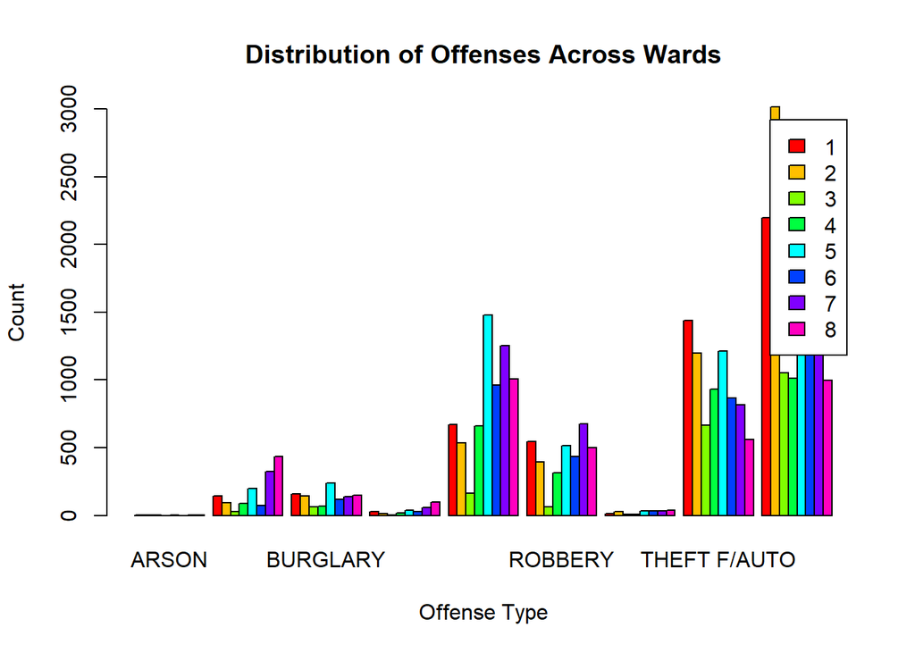

```r
# Step 2: Create a contingency table
ward_offense_table <- table(crime_data2$WARD, crime_data2$OFFENSE)

# Step 3: Visualize the data
# Use bar plot to visualize the distribution of offenses across wards
barplot(ward_offense_table, beside = TRUE, legend = TRUE,
        col = rainbow(nrow(ward_offense_table)),
        main = "Distribution of Offenses Across Wards",
        xlab = "Offense Type", ylab = "Count")
```

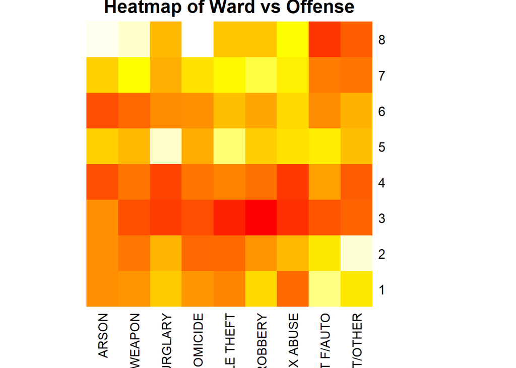

```r
# Heatmap to visualize relationship between Ward and Offense
heatmap(ward_offense_table, Rowv = NA, Colv = NA,
        col = heat.colors(256), scale = "column",
        main = "Heatmap of Ward vs Offense")
```

```r
# Step 4: Perform Chi-Square Test
chi_square_ward_offense <- chisq.test(ward_offense_table)

# Step 5: Print the results
print("Contingency Table:")
```

```
## [1] "Contingency Table:"
```

```r
print(ward_offense_table)
```

```
##
##     ARSON ASSAULT W/DANGEROUS WEAPON BURGLARY HOMICIDE MOTOR VEHICLE THEFT
##   1     1                        146      159       28                 672
##   2     1                         95      144       11                 535
##   3     1                         29       63        2                 164
##   4     0                         89       69       16                 663
##   5     2                        201      239       36                1481
##   6     0                         73      117       26                 961
##   7     2                        322      141       56                1254
##   8     4                        437      147       99                1006
##
##     ROBBERY SEX ABUSE THEFT F/AUTO THEFT/OTHER
##   1     547        15         1437        2195
##   2     395        26         1196        3015
##   3      63         7          666        1051
##   4     315         8          934        1010
##   5     517        32         1213        1848
##   6     433        31          869        1742
##   7     678        34          817        1221
##   8     502        36          558         996
```

```r
print("Chi-Square Test Results:")
```

```
## [1] "Chi-Square Test Results:"
```

```r
print(chi_square_ward_offense)
```

```
##
##  Pearson's Chi-squared test
##
## data:  ward_offense_table
## X-squared = 3590, df = 56, p-value <2e-16
```

```r
# Step 6: Interpretation
if (chi_square_ward_offense$p.value < 0.05) {
  print("Reject the null hypothesis: There is a significant association between the ward and the offense type.")
} else {
  print("Fail to reject the null hypothesis: There is no significant association between the ward and the offense type.")
}
```

```
## [1] "Reject the null hypothesis: There is a significant association between the ward and the offense type."
```

# 5.8)ANNOVA for district and ward

let check there is signofocant relation betweent the district and ward

```r
# Load necessary library
library(dplyr)
# Perform ANOVA
anova_result <- aov(DISTRICT ~ factor(WARD), data = crime_data2)

# Print the summary of ANOVA result
summary(anova_result)
```

```
##                 Df Sum Sq Mean Sq F value Pr(>F)
## factor(WARD)     7  80151   11450   10666 <2e-16 ***
## Residuals    33891  36383       1
## ---
## Signif. codes:  0 '***' 0.001 '**' 0.01 '*' 0.05 '.' 0.1 ' ' 1
```

```r
# Extract the p-value for the Ward variable (typically found in the first row of the ANOVA summary)
p_value <- summary(anova_result)[[1]][["Pr(>F)"]][1]

# Step 3: Use an if statement to check the p-value
if (p_value < 0.05) {
  print("Reject the null hypothesis: There are significant differences in crime rate across different Wards.")
} else {
  print("Fail to reject the null hypothesis: There are no significant differences in crime rate across different Wards.")
}
```

```
## [1] "Reject the null hypothesis: There are significant differences in crime rate across different Wards."
```

# Maps Of the DC

```r
library(tigris)
dc_wards <- state_legislative_districts(state = "dc", class='sf')
```

[output not shown]

# Gun offence-

In analyzing the crime data, we identified three primary methods of offense: Gun, Knife, and Other (which includes hands, sticks, rods, etc.). It is evident that gun-related offenses are associated with severe injuries and fatalities more frequently than other methods. Our findings indicate a strong correlation between gun offenses and specific wards and districts.

Given this insight, it is crucial to focus on the areas with high incidences of gun violence. By identifying these wards, law enforcement can strategically increase police surveillance and potentially establish additional police stations in hotspots. This proactive approach aims to enhance public safety and reduce gun-related incidents.

```r
# Load necessary libraries
library(tidyverse)
library(sf)
library(dplyr)
library(ggplot2)

gun_offenses <- crime_data2 %>%
  filter(METHOD == "GUN") %>%
  group_by(WARD) %>%
  summarize(gun_offense_count = n())

# Ensure the WARD column in gun_offenses is a character and match the format of NAMELSAD
gun_offenses <- gun_offenses %>%
  mutate(WARD = paste("Ward", as.character(WARD)))  # Add "Ward " prefix

# Merge dc_wards with gun offense counts
dc_ward_gun_offenses <- dc_wards %>%
  left_join(gun_offenses, by = c("NAMELSAD" = "WARD"))

# Check the structure of the merged data to confirm join
print(dim(dc_ward_gun_offenses))  # Print dimensions
```

```
## [1]  8 14
```

```r
print(head(dc_ward_gun_offenses))  # Preview the first few rows
```

```
## Simple feature collection with 6 features and 13 fields
## Geometry type: POLYGON
## Dimension:     XY
## Bounding box:  xmin: -77.1 ymin: 38.9 xmax: -76.9 ymax: 39
## Geodetic CRS:  NAD83
##   STATEFP SLDUST GEOID NAMELSAD LSAD  LSY MTFCC FUNCSTAT    ALAND  AWATER
## 1      11    001 11001   Ward 1   00 2022 G5210        N  6388973  182814
## 2      11    002 11002   Ward 2   00 2022 G5210        N 15329821 3029411
## 3      11    003 11003   Ward 3   00 2022 G5210        N 26957501 1316195
## 4      11    004 11004   Ward 4   00 2022 G5210        N 23011952  150161
## 5      11    005 11005   Ward 5   00 2022 G5210        N 26433039  403080
## 6      11    006 11006   Ward 6   00 2022 G5210        N 13696037 3894383
##      INTPTLAT     INTPTLON gun_offense_count                       geometry
## 1 +38.9252533 -077.0310006               441 POLYGON ((-77.1 38.9, -77.1...
## 2 +38.9001359 -077.0457772               333 POLYGON ((-77.1 38.9, -77.1...
## 3 +38.9382193 -077.0779791                37 POLYGON ((-77.1 38.9, -77.1...
## 4 +38.9638701 -077.0343018               285 POLYGON ((-77.1 39, -77.1 3...
## 5 +38.9255091 -076.9853522               466 POLYGON ((-77 38.9, -77 38....
## 6 +38.8813159 -077.0094205               377 POLYGON ((-77 38.9, -77 38....
```

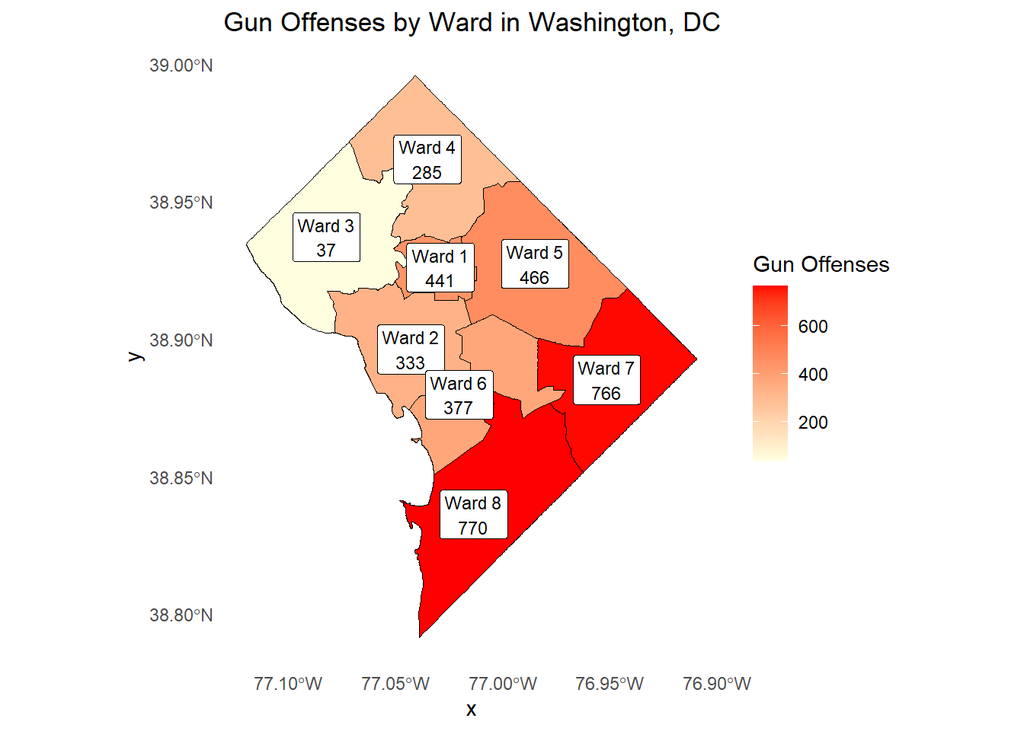

```r
# Plot the map
ggplot(dc_ward_gun_offenses) +
  geom_sf(aes(fill = gun_offense_count), color = "black") +  # Color by gun offense count
  geom_sf_label(aes(label = paste0(NAMELSAD, "\n", gun_offense_count)), size = 3) +  # Add ward labels
  scale_fill_gradient(low = "lightyellow", high = "red", na.value = "gray") +  # Color scale
  labs(title = "Gun Offenses by Ward in Washington, DC", fill = "Gun Offenses") +
  theme_minimal() +
  theme(panel.grid = element_blank())
```

```r
gun_offenses
```

```
## # A tibble: 8 × 2
##   WARD   gun_offense_count
##   <chr>              <int>
## 1 Ward 1               441
## 2 Ward 2               333
## 3 Ward 3                37
## 4 Ward 4               285
## 5 Ward 5               466
## 6 Ward 6               377
## 7 Ward 7               766
## 8 Ward 8               770
```

```r
#dc_ward_gun_offenses
#crime_data2
```

```r
# get tge boundries by districts.
dc_districts <- state_legislative_districts(state = "dc", class = 'sf')
```